# Introduction to R - PROJECT

Mateusz Mglej

2024-01-22

# Barnsley Fern

## Introduction[^1]

**Barnsley Fern** is a fractal popularized by Michael F. Barnsley. Its name comes from the resemblance to a fern leaf. It is an object that can be described using four affine transformations as the attractor of an iterated function system:

$$\begin{align}
f(x,y) &= (0.85x+0.04y, -0.04x+0.85y+1.6) \\
g(x,y) &= (-0.15x+0.28y, 0.26x+0.24y+0.44) \\
h(x,y) &= (0.20x-0.26y, 0.23x+0.22y+1.6) \\
k(x,y) &= (0, 0.16y)
\end{align}$$
Generating the Barnsley fern is based on randomly using the above transformations with probabilities $85:7:7:1$. The algorithm iterates the coordinates of the plotted point by repeatedly applying one of the transformations. We start with an initial point $(x_0,y_0)=(0,0)$, and at each step randomly select a transformation based on the given probabilities to compute the next point. The process is repeated a specified number of times.

## Algorithm code

```r
fern <- function(p){
  a=0.0; b=0.0  # coordinates to be transformed
  x = NULL; y = NULL  # vectors for generated coordinates
  n=1

  while(n < p + 1){
    r = runif(1)
    if(r < 0.01){
      x[n] = 0.0; y[n] = 0.16 * b
    } else if(r < 0.86){
      x[n] = 0.85 * a + 0.04 * b; y[n] = -0.04 * a + 0.85 * b + 1.6
    } else if(r < 0.93){
      x[n] = 0.2 * a - 0.26 * b; y[n] = 0.23 * a + 0.22 * b + 1.6
    } else {
      x[n] = -0.15 * a + 0.28 * b; y[n] = 0.26 * a + 0.24 * b + 0.44
    }
    a = x[n]; b = y[n]; n = n + 1
  }

  data = data.frame(x, y)
  ggplot() +
    geom_point(data = data, aes(x = x, y = y), colour = 'green4', size = 1, shape = '.') +
    labs(title = "Barnsley Fern", subtitle = paste("Number of iterations:", number(p))) +
    theme(axis.line = element_blank(),
          axis.text.x = element_blank(),
          axis.text.y = element_blank(),
          axis.ticks = element_blank(),
          axis.title.x = element_blank(),
          axis.title.y = element_blank(),
          panel.grid.major = element_blank(),
          panel.grid.minor = element_blank(),
          plot.background = element_rect(fill = "#fafcff"),
          panel.background = element_rect(fill = "#fafcff"),
          plot.title = element_text(face = "bold", size = 20, colour = 'firebrick4'),
          plot.subtitle = element_text(face = "bold", size = 15, colour = "blue4"))
}
```

## Result of the algorithm for 500,000 iterations

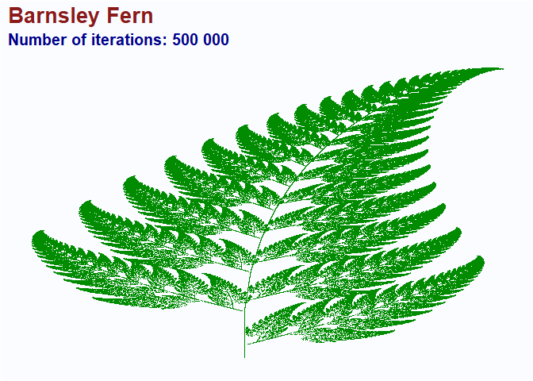

```r
fern(500000)
```

# Wind Measurement Data Analysis

## Loading the data

In my case, it will be the file **dane_3.xlsx**, loaded from the current folder.

```r
dane_3=read_excel("dane_3.xlsx")
```

## Creating a new data frame

```r
CH7 = dane_3$CH7Avg

sektor=NULL
sektor[which(CH7 <= 45 | CH7 > 315)] = "N"
sektor[which(CH7 > 45 & CH7 <= 135)] = "E"
sektor[which(CH7 > 135 & CH7 <= 225)]= "S"
sektor[which(CH7 > 225 & CH7 <= 315)]= "W"

ramka.danych = data.frame(date = dane_3$`Date & Time Stamp`,
                          anemo_80m = dane_3$CH4Avg,
                          anemo_60m = dane_3$CH5Avg,
                          anemo_40m = dane_3$CH6Avg,
                          kierunek_78m = dane_3$CH7Avg,
                          sector = sektor)
head(ramka.danych)
```

```
##                  date anemo_80m anemo_60m anemo_40m kierunek_78m sector
## 1 2010-11-01 00:00:00       7.0       5.9       4.8          166      S
## 2 2010-11-01 00:10:00       6.5       5.3       4.1          170      S
## 3 2010-11-01 00:20:00       7.0       5.9       4.9          171      S
## 4 2010-11-01 00:30:00       8.2       6.9       5.7          170      S
## 5 2010-11-01 00:40:00       8.4       7.1       5.9          167      S
## 6 2010-11-01 00:50:00       9.1       7.9       6.7          169      S
```

## Plot theme template

```r
szablon = theme(plot.title = element_text(face = "bold", size = (18), colour='firebrick4'),
        plot.subtitle = element_text(face='italic', size=(15), colour="wheat4"),
        legend.title = element_text(face = "bold.italic", size = 18, colour='blue4'),
        legend.text = element_text(face = "bold.italic", size = (12), colour="darkslategrey"),
        plot.caption = element_text(color = "red"),
        axis.title = element_text(face='bold', size = (13), colour="darkslategrey"),
        axis.text = element_text(face='bold', colour = "steelblue", size = (11)),
        plot.background = element_rect(fill = "#fafcff"),
        legend.background = element_rect(fill='#fafcff'),
        legend.key = element_rect(fill = "#fafcff"),
        panel.background = element_rect(fill = '#f5f5f5'),
        legend.title.align = .5,)
```

## Wind speed from all anemometers over time

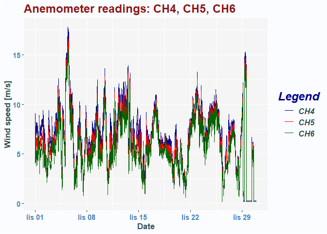

```r
ggplot()+
  geom_line(data=ramka.danych,aes(x=date, y=anemo_80m, colour="CH4"),linewidth=0.7) +
  geom_line(data=ramka.danych,aes(x=date, y=anemo_60m, colour="CH5"),linewidth=0.7) +
  geom_line(data=ramka.danych,aes(x=date, y=anemo_40m, colour="CH6"),linewidth=0.7) +
  scale_color_manual(name = "Legend", values = c("CH4" = "darkblue","CH5" = "red","CH6"="darkgreen"))+
  labs(title="Anemometer readings: CH4, CH5, CH6", x="Date", y="Wind speed [m/s]")+
  szablon
```

On the plot, we clearly see problems after November 29, with three continuous measurement periods where values are close to 0 (possible sensor freezing).

I define faulty data as measurements with values below *0.5*. In general, we should also check air temperature and standard deviation of wind speed, but visual inspection of this dataset shows the above condition is sufficient. Then, I extract such values and create a new frame without them.

```r
A = which(ramka.danych$anemo_40m<0.5)
B = which(ramka.danych$anemo_60m<0.5)
C = which(ramka.danych$anemo_80m<0.5)
ABC = union(union(A,B),C)

ramka.test = ramka.danych[ABC,]
head(ramka.test)
```

```
##                     date anemo_80m anemo_60m anemo_40m kierunek_78m sector
## 3642 2010-11-26 06:50:00       0.2       0.3       0.3          219      S
## 3643 2010-11-26 07:00:00       0.2       0.3       0.3          213      S
## 4058 2010-11-29 04:10:00       0.2       0.3       0.3           58      E
## 4059 2010-11-29 04:20:00       0.2       0.3       0.3           59      E
## 4060 2010-11-29 04:30:00       0.2       0.3       0.3           58      E
## 4061 2010-11-29 04:40:00       0.2       0.3       0.3           60      E
```

```r
ramka = ramka.danych[-ABC,]
```

The full set of faulty data **ramka.test** consists of readings where one anemometer shows a constant value of *0.2*, and the other two show *0.3*. A preview is shown above.

## Wind vertical profile

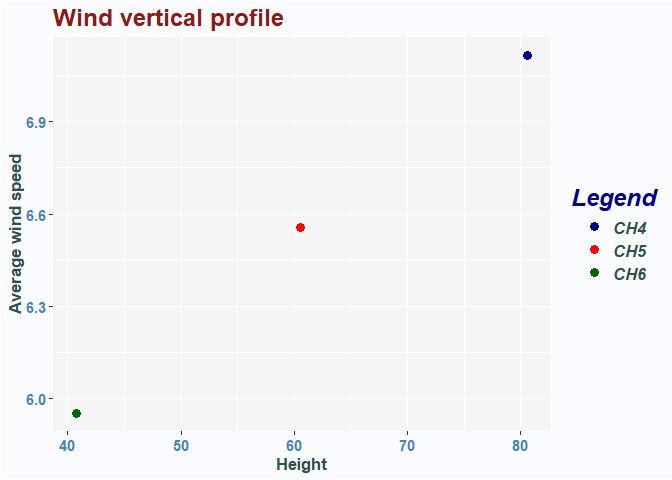

```r
# anemometer heights
hCH4 = 80.62
hCH5 = 60.53
hCH6 = 40.73

# average wind speeds
CH4 = mean(ramka$anemo_80m)
CH5 = mean(ramka$anemo_60m)
CH6 = mean(ramka$anemo_40m)

wysokosc = c(hCH4,hCH5,hCH6)
srednie = c(CH4,CH5,CH6)
nazwy = c("CH4","CH5","CH6")

# wind vertical profile
ggplot()+
  geom_point(aes(wysokosc, srednie, color=nazwy), size=3)+
  labs(x="Height",y="Average wind speed",title="Wind vertical profile")+
  scale_color_manual(name = "Legend", values = c("CH4" = "darkblue","CH5" = "red","CH6"="darkgreen"))+
  szablon
```

## Wind speed plots using Hellmann and logarithmic formulas

### Hellmann–Sutton power law

Hellmann–Sutton formula:
$$\begin{align}
V(h)=V_1*\left(\frac{h}{h_1}\right)^w
\end{align}$$

Where:

- $h_1$ — reference height
- $V_1$ — average wind speed at the reference height
- $w$ — exponent characteristic for the location

Based on our data, we calculate the value of $w$, then define a function that estimates wind speed for a given height.

```r
h1 = hCH4
V1 = mean(ramka$anemo_80m)
h2 = hCH6
V2 = mean(ramka$anemo_40m)
w = log(V2/V1, base=h2/h1)

V.Hell = function(h){
  return(V1*(h/h1)**w)
}
```

### Logarithmic wind profile law

Logarithmic law:
$$V(h)=V_1*\frac{ln(h/z_0)}{ln(h_1/z_0)}$$
Where:

- $h_1$ — reference height
- $V_1$ — average wind speed at the reference height
- $z_0$ — surface roughness coefficient

Now we compute $z_0$ and define the function.

```r
z0 = ((h1**(V2/V1))/h2)**(1/((V2/V1)-1))

V.Log = function(h){
  return(V1*(log(h/z0)/log(h1/z0)))
}
```

### Wind speed graph

The plot shows both formulas together with data-based points.

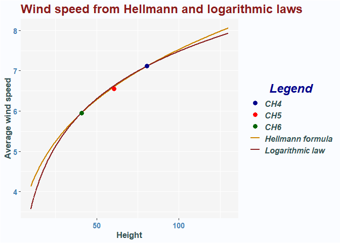

```r
h = seq(10,130,by=0.1)

ggplot()+
  geom_line(aes(h,V.Hell(h),color="Hellmann formula"), linewidth=1)+
  geom_line(aes(h,V.Log(h),color="Logarithmic law"), linewidth=1)+
  geom_point(aes(wysokosc, srednie, color=nazwy), size=3)+
  labs(x="Height",y="Average wind speed",title="Wind speed from Hellmann and logarithmic laws")+
  scale_color_manual(name = "Legend", values = c("CH4" = "darkblue","CH5" = "red","CH6"="darkgreen","Hellmann formula"="orange3","Logarithmic law"="brown4"))+
  szablon
```

## Histogram and Weibull parameter estimation with density curve

For each anemometer, we estimate Weibull distribution parameters and overlay a density curve on a histogram.

### CH4

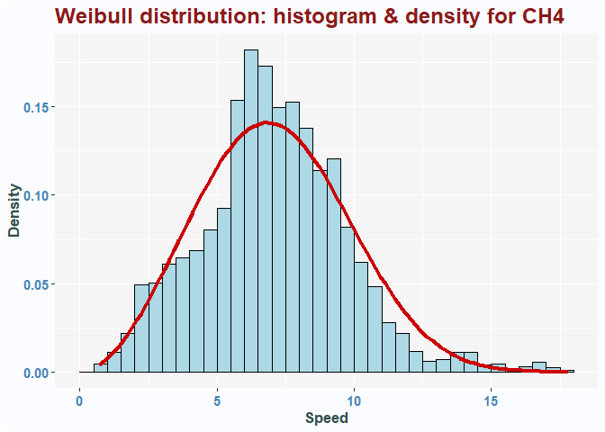

```r
podzial = seq(0,max(ramka$anemo_80m)+ 0.5, by = 0.5)
x=seq(from=0,to=16,by=0.1)

estymacja = eweibull(ramka$anemo_80m)
shape = estymacja$parameters[1]
scale = estymacja$parameters[2]

ggplot(data = ramka, aes(x = anemo_80m)) +
  geom_histogram(aes(y = after_stat(density)), breaks = podzial, fill = "lightblue", color = "black") +
  stat_function(fun = dweibull, args = list(shape = shape, scale = scale), color = "red3", linewidth = 1.5)+
  labs(x="Speed",y="Density",title="Weibull distribution: histogram & density for CH4")+
  szablon
```

### CH5

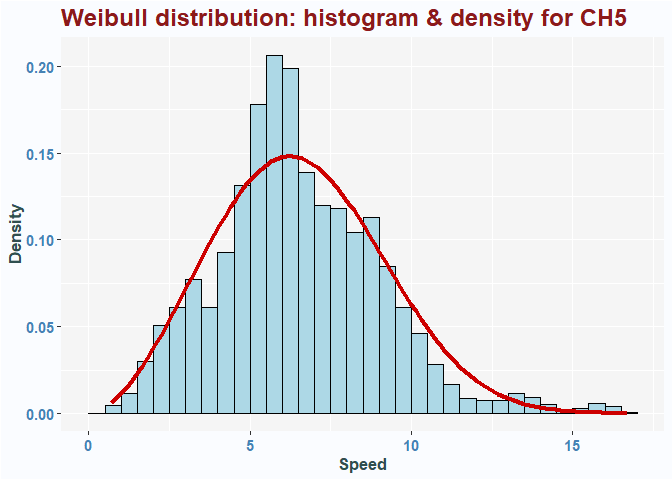

```r
podzial = seq(0,max(ramka$anemo_60m)+ 0.5, by = 0.5)
x=seq(from=0,to=16,by=0.1)

estymacja = eweibull(ramka$anemo_60m)
shape = estymacja$parameters[1]
scale = estymacja$parameters[2]

ggplot(data = ramka, aes(x = anemo_60m)) +
  geom_histogram(aes(y = after_stat(density)), breaks = podzial, fill = "lightblue", color = "black") +
  stat_function(fun = dweibull, args = list(shape = shape, scale = scale), color = "red3", linewidth = 1.5)+
  labs(x="Speed",y="Density",title="Weibull distribution: histogram & density for CH5")+
  szablon
```

### CH6

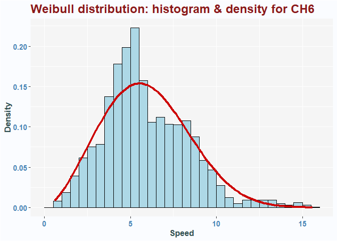

```r
podzial = seq(0,max(ramka$anemo_40m)+ 0.5, by = 0.5)
x=seq(from=0,to=16,by=0.1)

estymacja = eweibull(ramka$anemo_40m)
shape = estymacja$parameters[1]
scale = estymacja$parameters[2]

ggplot(data = ramka, aes(x = anemo_40m)) +
  geom_histogram(aes(y = after_stat(density)), breaks = podzial, fill = "lightblue", color = "black") +
  stat_function(fun = dweibull, args = list(shape = shape, scale = scale), color = "red3", linewidth = 1.5)+
  labs(x="Speed",y="Density",title="Weibull distribution: histogram & density for CH6")+
  szablon
```

## CH4Avg speed histogram by wind sectors (4 panels)

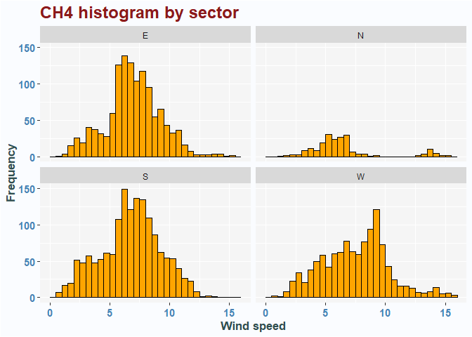

```r
ggplot(ramka ,aes(anemo_80m))+
  geom_histogram(breaks = seq(0,16,by=0.5),color="black",fill="orange")+
  facet_wrap(~sector)+
  labs(title="CH4 histogram by sector",x="Wind speed",y="Frequency")+
  szablon
```

## CH4Avg speed plot by sectors on a single panel

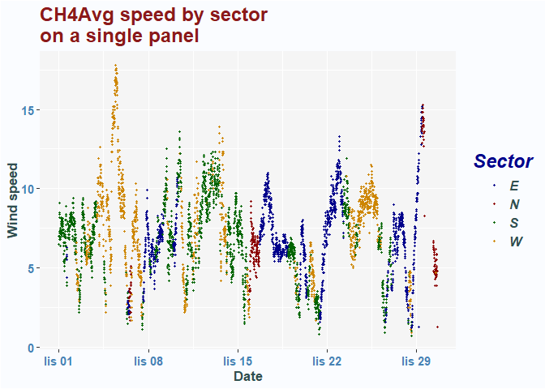

```r
ggplot(ramka, aes(x = date, y = anemo_80m, colour = sector))+
  geom_point(size = 0.75)+
  labs(title = "CH4Avg speed by sector \non a single panel",x = "Date", y = "Wind speed")+
  scale_color_manual(name = "Sector", values = c("E" = "blue4","N" = "red4","S"="darkgreen","W"="orange3"))+
  szablon
```

## Boxplot of CH4Avg wind speed by sectors (4 panels)

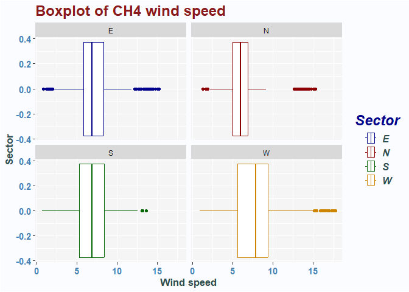

```r
ggplot(ramka, aes(x=anemo_80m, colour=sector)) +
  geom_boxplot()+
  facet_wrap(~sector, ncol = 2)+
  scale_color_manual(name="Sector",values = c("E" = "blue4","N" = "red4","S"="darkgreen","W"="orange3"))+
  labs(title="Boxplot of CH4 wind speed",x="Wind speed",y="Sector")+
  szablon
```

[^1]: https://en.wikipedia.org/wiki/Barnsley_fern